# Cluster Creation Hyrox Dataset - UK Women

Jojo Justine

2025-06-02

```r
#install.packages("countrycode")
#install.packages("rsample")
#install.packages("fmsb")
#install.packages("factoextra")
```

## Finding Number of Clusters

**Elbow Method**

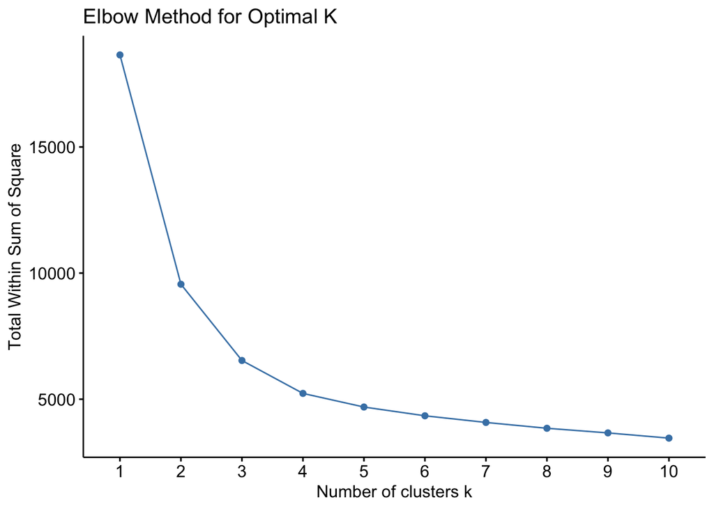

```r
# Read the CSV file
df <- read.csv("hyrox_results_updated_V4.csv")

# Filter UK female who completed the race
df_filtered <- df %>%
  filter(gender == "female",
         country == "United Kingdom",
         completed == "Yes",
         !is.na(total_time)) %>%
  filter(if_all(starts_with("run_"), ~ .x > 60))  # Exclude unrealistic values

# Select run split columns
run_columns <- paste0("run_", 1:8)

# Extract run splits and drop NAs
run_data <- df_filtered %>%
  select(all_of(run_columns)) %>%
  drop_na()

# Scale data for clustering
run_scaled <- scale(run_data)

# Use fviz_nbclust to find optimal number of clusters
fviz_nbclust(run_scaled, kmeans, method = "wss",
             k.max = 10,
             nstart = 10,
             diss = NULL) +
  labs(title = "Elbow Method for Optimal K")
```

**Silhouette Method**

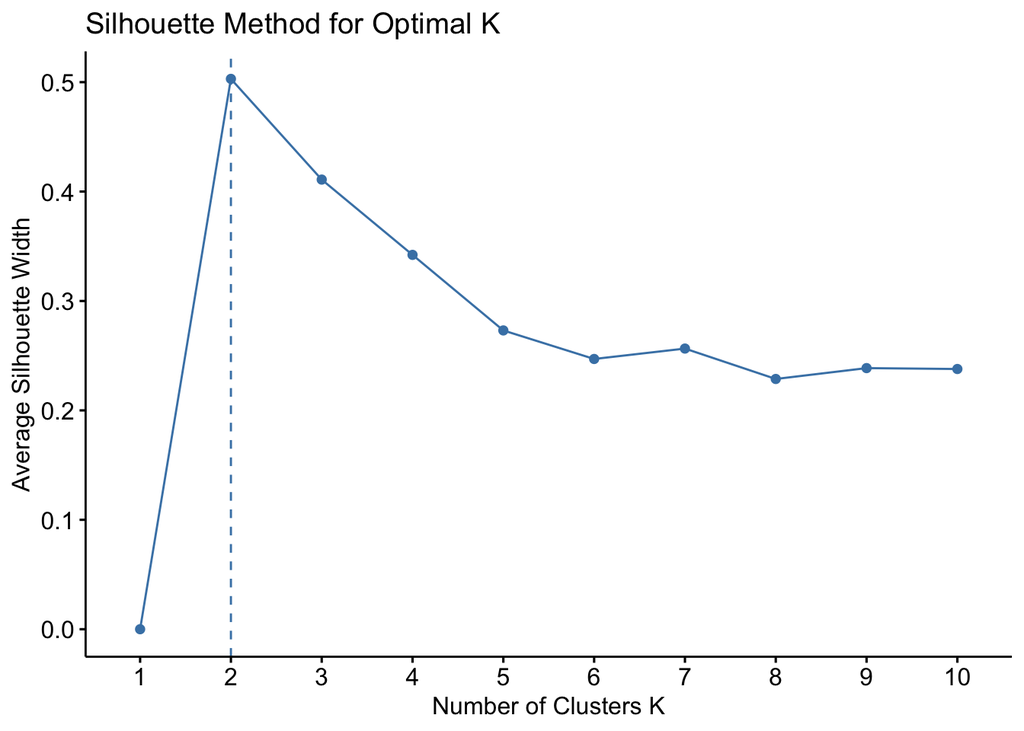

```r
fviz_nbclust(run_scaled, kmeans, method = "silhouette",
             k.max = 10, nstart = 10) +
  labs(title = "Silhouette Method for Optimal K",
       x = "Number of Clusters K",
       y = "Average Silhouette Width")
```

Even though Elbow and Silhouette method is suggesting 2 clusters, we are classifying pacing strategies into three performance tiers: top, average, and bottom.

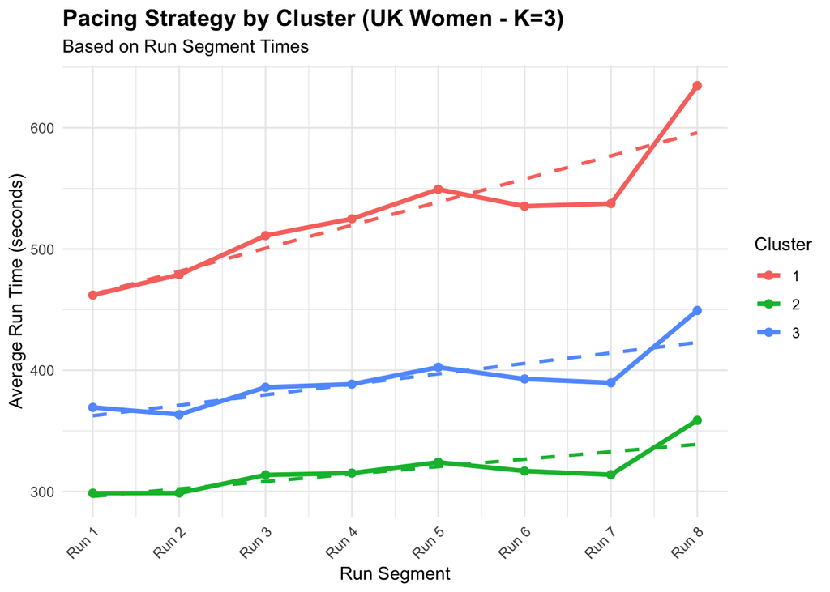

```r
# Apply k-means clustering (with k = 3)
set.seed(42)
km <- kmeans(run_scaled, centers = 3, nstart = 25)

# Add cluster labels to the full dataset
df_clustered <- df_filtered %>%
  filter(!is.na(run_1)) %>%
  mutate(Cluster = factor(km$cluster))

# Pivot data for plotting
df_long <- df_clustered %>%
  select(all_of(run_columns), Cluster) %>%
  pivot_longer(-Cluster, names_to = "Run", values_to = "Time")

# Convert Run to numeric index and keep the label
df_long <- df_long %>%
  mutate(Run_num = as.numeric(gsub("run_", "", Run)),
         Run_label = paste0("Run ", Run_num))

ggplot(df_long, aes(x = Run_num, y = Time, color = Cluster, group = Cluster)) +
  stat_summary(fun = mean, geom = "line", size = 1.3) +
  stat_summary(fun = mean, geom = "point", size = 2) +
  geom_smooth(method = "lm", se = FALSE, linetype = "dashed", size = 1) +
  scale_x_continuous(breaks = 1:8, labels = paste0("Run ", 1:8)) +  # Set correct x-axis
  labs(title = "Pacing Strategy by Cluster (UK Women - K=3)",
       subtitle = "Based on Run Segment Times",
       y = "Average Run Time (seconds)",
       x = "Run Segment") +
  theme_minimal() +
  theme(axis.text.x = element_text(angle = 45, hjust = 1),
        plot.title = element_text(size = 14, face = "bold"),
        plot.subtitle = element_text(size = 11))
```

Added Regression lines to each clusters.  
Cluster 2 (Green) has lowest run times throughout, consistently around 300–350 seconds.This has the most consistent pacing strategy, with only slight increases and stable pacing across all run segments.  
Run 8 takes longer for everyone, across all clusters. This suggests it’s a tough part of the race—probably because athletes are tired, close to the finish, or just completed a hard workout like the sandbag lunges

**Individual Pacing Lines by Cluster**

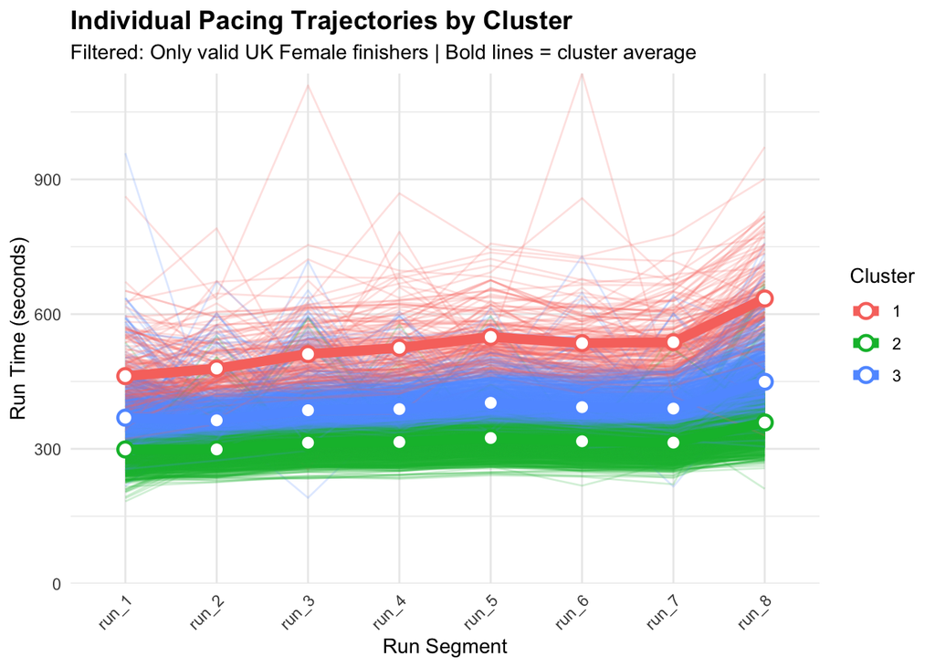

```r
# Prepare long format for individual trajectories
df_long_individual <- df_clustered %>%
  select(all_of(run_columns), Cluster) %>%
  mutate(AthleteID = row_number()) %>%
  pivot_longer(cols = starts_with("run_"), names_to = "Run", values_to = "Time")

# Plot individual lines with transparency, grouped by cluster
ggplot(df_long_individual, aes(x = Run, y = Time, group = AthleteID, color = Cluster)) +
  geom_line(alpha = 0.2) +  # Keep individual pacing lines clearly visible
  stat_summary(aes(group = Cluster), fun = mean, geom = "line", size = 2.5, alpha = 1) +  # Thicker average line
  stat_summary(aes(group = Cluster), fun = mean, geom = "point", size = 3, shape = 21, fill = "white", stroke = 1.2) +  # Highlighted average points
  labs(title = "Individual Pacing Trajectories by Cluster",
       subtitle = "Filtered: Only valid UK Female finishers | Bold lines = cluster average",
       x = "Run Segment", y = "Run Time (seconds)") +
  scale_y_continuous(limits = c(0, NA), expand = c(0, 0)) +
  theme_minimal() +
  theme(axis.text.x = element_text(angle = 45, hjust = 1),
        plot.title = element_text(size = 14, face = "bold"),
        plot.subtitle = element_text(size = 11))
```

The bold lines with white circles represent the average pacing trajectory for each cluster. The thin transparent lines show individual runners’ pacing.Green cluster runners are tightly packed, showing very similar pacing and better control.

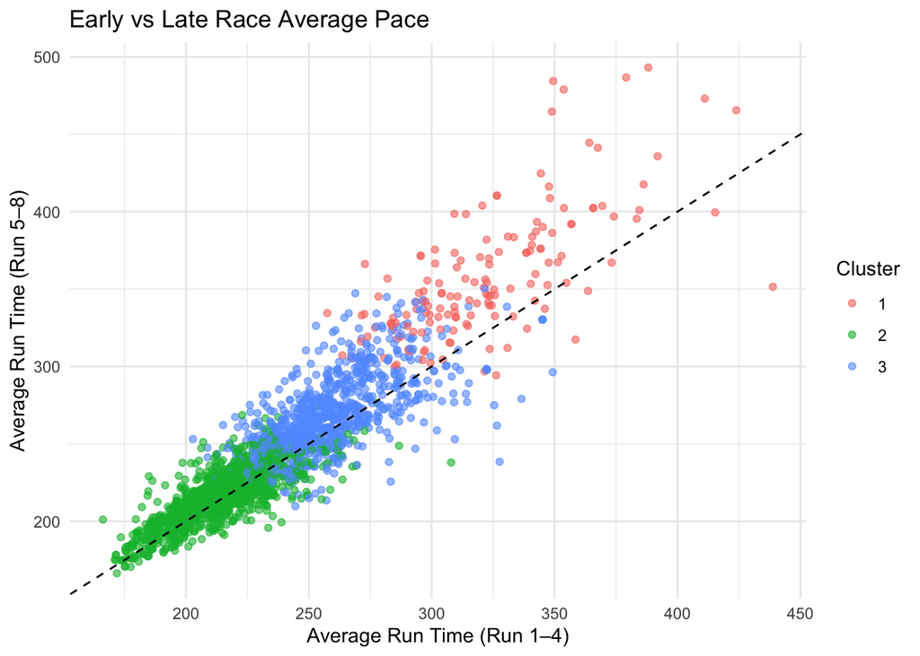

```r
df_clustered %>%
  mutate(Early = rowMeans(select(., run_1:run_4), na.rm = TRUE),
         Late = rowMeans(select(., run_5:run_8), na.rm = TRUE)) %>%
  ggplot(aes(x = Early, y = Late, color = Cluster)) +
  geom_point(alpha = 0.6) +
  geom_abline(slope = 1, intercept = 0, linetype = "dashed") +
  labs(title = "Early vs Late Race Average Pace",
       x = "Average Run Time (Run 1–4)",
       y = "Average Run Time (Run 5–8)") +
  theme_minimal()
```

The above plot compares each athlete’s average run time during the first half of the race (Runs 1–4) to their average run time in the second half (Runs 5–8), grouped by cluster. Athletes in the green cluster maintained a very steady pace and are the fastest.

**Clustering Including total_time along with individual run times**

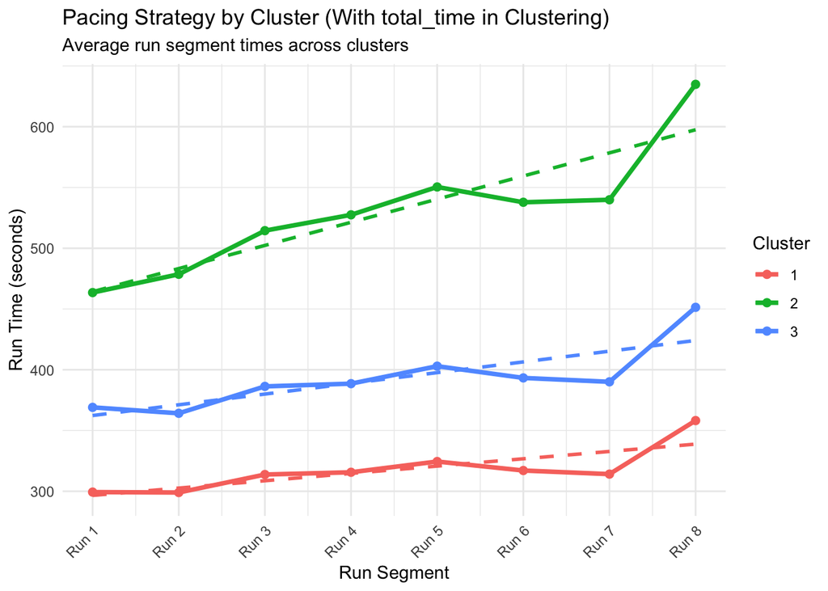

```r
# Add total_time to run splits
run_columns <- paste0("run_", 1:8)
cluster_data <- df_filtered %>%
  select(all_of(run_columns), total_time) %>%
  drop_na()

# Scale all columns
cluster_scaled <- scale(cluster_data)

# Apply K-means
set.seed(42)
km_with_total <- kmeans(cluster_scaled, centers = 3, nstart = 25)

# Assign back to original filtered data
df_clustered <- df_filtered %>%
  filter(!is.na(run_1)) %>%
  mutate(Cluster = factor(km_with_total$cluster))

# Prepare long format for pacing plot
df_long_total <- df_clustered %>%
  select(all_of(run_columns), Cluster) %>%
  pivot_longer(cols = all_of(run_columns), names_to = "Run", values_to = "Time")

df_long_total <- df_long_total %>%
  mutate(Run_num = as.numeric(gsub("run_", "", Run)))

ggplot(df_long_total, aes(x = Run_num, y = Time, color = Cluster, group = Cluster)) +
  stat_summary(fun = mean, geom = "line", size = 1.3) +         # Mean pacing line
  stat_summary(fun = mean, geom = "point", size = 2) +          # Mean points
  geom_smooth(method = "lm", se = FALSE, linetype = "dashed", size = 1) +  # Regression line
  scale_x_continuous(breaks = 1:8, labels = paste0("Run ", 1:8)) +
  labs(title = "Pacing Strategy by Cluster (With total_time in Clustering)",
       subtitle = "Average run segment times across clusters",
       y = "Run Time (seconds)", x = "Run Segment") +
  theme_minimal() +
  theme(axis.text.x = element_text(angle = 45, hjust = 1))
```

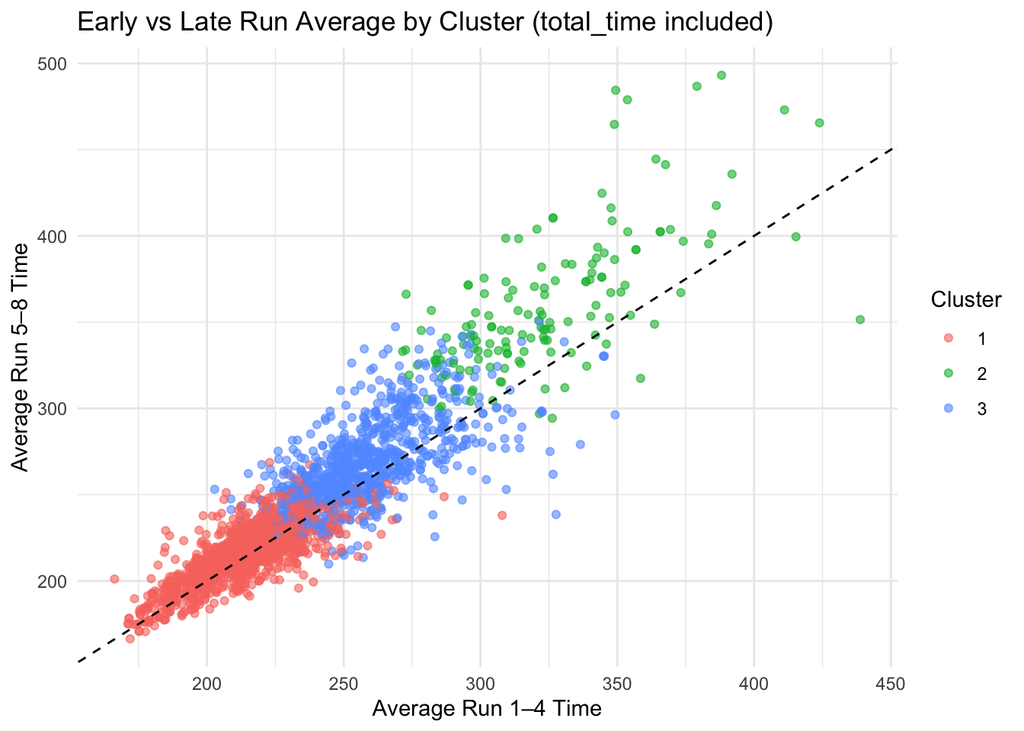

```r
df_clustered %>%
  mutate(Early = rowMeans(select(., run_1:run_4), na.rm = TRUE),
         Late = rowMeans(select(., run_5:run_8), na.rm = TRUE)) %>%
  ggplot(aes(x = Early, y = Late, color = Cluster)) +
  geom_point(alpha = 0.6) +
  geom_abline(linetype = "dashed") +
  labs(title = "Early vs Late Run Average by Cluster (total_time included)",
       x = "Average Run 1–4 Time", y = "Average Run 5–8 Time") +
  theme_minimal()
```

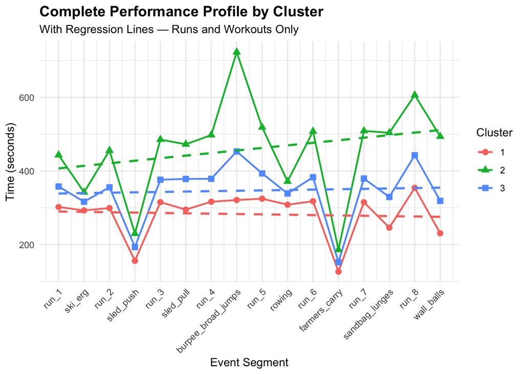

```r
# Define columns (clustering includes total_time)
event_columns <- c(
  "total_time",
  "run_1", "ski_erg",
  "run_2", "sled_push",
  "run_3", "sled_pull",
  "run_4", "burpee_broad_jumps",
  "run_5", "rowing",
  "run_6", "farmers_carry",
  "run_7", "sandbag_lunges",
  "run_8", "wall_balls"
)

# Prepare data and scale
event_data <- df_filtered %>%
  select(all_of(event_columns)) %>%
  drop_na()

event_scaled <- scale(event_data)

# Perform K-means clustering
set.seed(42)
km_events <- kmeans(event_scaled, centers = 3, nstart = 25)

# Add cluster info
df_clustered_events <- df_filtered %>%
  filter(!is.na(run_1)) %>%
  mutate(Cluster = factor(km_events$cluster))

# Prepare data for plotting (exclude total_time)
plot_columns <- event_columns[event_columns != "total_time"]

df_long_events <- df_clustered_events %>%
  select(all_of(plot_columns), Cluster) %>%
  pivot_longer(cols = all_of(plot_columns), names_to = "Event", values_to = "Time")

# Add event index for regression
df_long_events <- df_long_events %>%
  mutate(Event = factor(Event, levels = plot_columns),
         Event_num = as.numeric(Event))  # For regression

# Plot with regression lines
ggplot(df_long_events, aes(x = Event_num, y = Time, color = Cluster, group = Cluster)) +
  stat_summary(fun = mean, geom = "line", size = 0.8) +  # Cluster average lines
  stat_summary(fun = mean, geom = "point", aes(shape = Cluster), size = 2.5) +  # Cluster average points
  geom_smooth(method = "lm", se = FALSE, linetype = "dashed", size = 1) +  # Regression lines per cluster
  scale_x_continuous(breaks = 1:length(plot_columns), labels = plot_columns) +  # Match event labels
  labs(title = "Complete Performance Profile by Cluster",
       subtitle = "With Regression Lines — Runs and Workouts Only",
       y = "Time (seconds)", x = "Event Segment") +
  theme_minimal() +
  theme(axis.text.x = element_text(angle = 45, hjust = 1),
        plot.title = element_text(size = 14, face = "bold"),
        plot.subtitle = element_text(size = 11))
```

The above plot shows how each cluster performed across all running and workout events. The red group (Cluster 1) was the fastest and most consistent, with lower times throughout. The blue group (Cluster 3) was in the middle, showing steady pacing but slightly slower. The green group (Cluster 2) was the slowest overall and showed the most variation, with major slowdowns in events like burpee broad jumps and run 8, suggesting they struggled more in the later and more demanding parts of the race. The dotted lines (regression) show that slower groups tend to slow down even more over time.

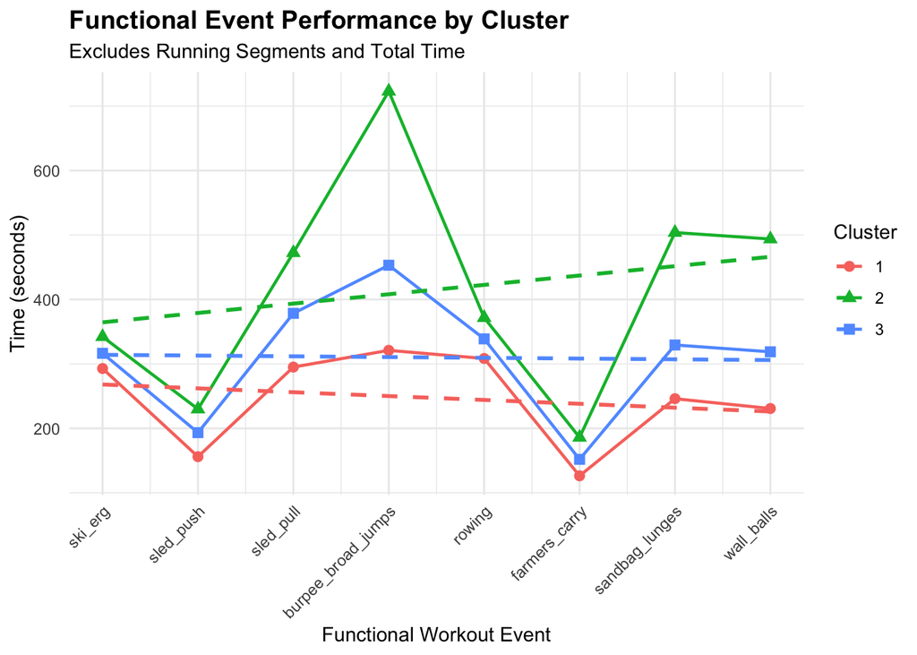

```r
# Define full and functional event columns
event_columns <- c(
  "total_time",
  "run_1", "ski_erg",
  "run_2", "sled_push",
  "run_3", "sled_pull",
  "run_4", "burpee_broad_jumps",
  "run_5", "rowing",
  "run_6", "farmers_carry",
  "run_7", "sandbag_lunges",
  "run_8", "wall_balls"
)

functional_events <- c(
  "ski_erg", "sled_push", "sled_pull", "burpee_broad_jumps",
  "rowing", "farmers_carry", "sandbag_lunges", "wall_balls"
)

# Prepare data and scale
event_data <- df_filtered %>%
  select(all_of(event_columns)) %>%
  drop_na()

event_scaled <- scale(event_data)

# Perform K-means clustering
set.seed(42)
km_events <- kmeans(event_scaled, centers = 3, nstart = 25)

# Assign cluster to original dataset
df_clustered_events <- df_filtered %>%
  filter(!is.na(run_1)) %>%
  mutate(Cluster = factor(km_events$cluster))

# Prepare long-format data for functional events only
df_long_functional <- df_clustered_events %>%
  select(all_of(functional_events), Cluster) %>%
  pivot_longer(cols = all_of(functional_events), names_to = "Event", values_to = "Time") %>%
  mutate(Event = factor(Event, levels = functional_events),
         Event_num = as.numeric(Event))  # Needed for regression

# Plot
ggplot(df_long_functional, aes(x = Event_num, y = Time, color = Cluster, group = Cluster)) +
  stat_summary(fun = mean, geom = "line", size = 0.8) +
  stat_summary(fun = mean, geom = "point", aes(shape = Cluster), size = 2.5) +
  geom_smooth(method = "lm", se = FALSE, linetype = "dashed", size = 1) +
  scale_x_continuous(breaks = 1:8, labels = functional_events) +
  labs(title = "Functional Event Performance by Cluster",
       subtitle = "Excludes Running Segments and Total Time",
       y = "Time (seconds)", x = "Functional Workout Event") +
  theme_minimal() +
  theme(axis.text.x = element_text(angle = 45, hjust = 1),
        plot.title = element_text(size = 14, face = "bold"),
        plot.subtitle = element_text(size = 11))
```

The red group (Cluster 1) performed the best overall, with the fastest times across almost all functional workout events. The blue group (Cluster 3) was slower but fairly consistent. The green group (Cluster 2) was the slowest, with large spikes in events like burpee broad jumps, and sandbag lunges showing that they struggled the most in those workouts.